# Análisis Multivariado

- Mostrar todo el código
- Ocultar todo el código
- Ver el código fuente

Unidad II: Métodos Factoriales — Práctico

Autores/as

Pablo Ortiz

María Inés Stimolo

Fecha de publicación

23 de septiembre de 2026

# 1 Introducción

En la primera parte de esta unidad, el ACP partía de una matriz de datos y buscaba direcciones de máxima varianza mediante una descomposición en valores y vectores propios. Los tres métodos de este práctico retoman esa misma idea con variaciones:

| Método | Parte de | Métrica | Tipo |
| --- | --- | --- | --- |
| ACP (primera parte) | matriz de datos | euclídea | descriptivo |
| Escalado multidimensional | matriz de **distancias** | euclídea (métrico) / orden (no métrico) | descriptivo |
| Correspondencias | tabla de **frecuencias** | chi-cuadrado sobre perfiles | descriptivo |
| Factorial | matriz de datos | — | **con modelo** |

El escalado multidimensional y el análisis de correspondencias cambian el insumo (una matriz de distancias, una tabla de frecuencias) y la métrica, pero conservan el mecanismo: proyectar en pocas dimensiones a partir de una descomposición espectral. El análisis factorial rompe ese patrón: en vez de transformar los datos observados, propone un **modelo** con variables latentes no observadas y parámetros a estimar.

Como primer ejemplo de esa continuidad: si se calculan distancias euclídeas sobre datos estandarizados y se les aplica escalado multidimensional clásico, el resultado coincide exactamente (salvo el signo de los ejes) con las dos primeras componentes principales de esos mismos datos. La sección Sección 3.2 lo verifica numéricamente, una vez presentada la base que se usa para eso.

**TipMaterial del práctico**

Todo el código de este documento está disponible como script de R en el repositorio de la materia:

- [Descargar `Unidad2b_Metodos_factoriales.R`](https://raw.githubusercontent.com/pabort/MAE-Multivariado/main/Unidad2b_Metodos_factoriales.R) (clic derecho → “Guardar enlace como…”)
- [Ver el repositorio completo](https://github.com/pabort/MAE-Multivariado)

El script está organizado en las mismas secciones que este documento, así que se puede navegar desde el índice de RStudio (Ctrl+Shift+O).

**Mostrar código**

```r
for (loc in c("es_AR.UTF-8", "es_ES.UTF-8", "en_US.UTF-8", "C.UTF-8", "C.utf8")) {
  if (Sys.setlocale("LC_CTYPE", loc) != "") break
}

library(factoextra)    # visualización de ACP y correspondencias
library(FactoMineR)    # correspondencias simples y múltiples
library(ca)             # correspondencias, como contraste de FactoMineR
library(MASS)           # isoMDS (escalado no métrico)
library(psych)          # métodos de estimación del análisis factorial
library(GPArotation)    # rotación quartimax para factanal()
library(tidyverse)      # al final, para que dplyr::select() no quede enmascarado

theme_set(theme_minimal(base_size = 11))
```

# 2 Carga de paquetes y datos

Los cuatro conjuntos de datos de este práctico se leen directamente por URL, sin necesidad de descargar nada:

## 2.1 Los conjuntos de datos

| Dataset | Contenido | Tamaño | Fuente |
| --- | --- | --- | --- |
| `ciudades_espania` | distancias por carretera (km) entre Madrid, Barcelona, Valencia, Sevilla, San Sebastián y La Coruña | 6 × 6 | Peña (2002) |
| `productos` | disimilitudes percibidas entre 7 productos, en una escala subjetiva de 0 a 9 | 7 × 7 | Peña (2002) |
| `eph` | Encuesta Permanente de Hogares (INDEC): sexo, estado civil, nivel educativo y condición de actividad | 282 casos × 4 variables | INDEC |
| `epf` | Encuesta de Presupuestos Familiares 1990/91 de España: gasto en 9 rubros de consumo | 51 provincias (Ceuta y Melilla unidas) × 9 variables | INE (España) |

**Mostrar código**

```r
url_base <- "https://raw.githubusercontent.com/pabort/MAE-Multivariado/main/"

ciudades <- read_csv(paste0(url_base, "ciudades_espania.csv"), show_col_types = FALSE) |>
  as.data.frame()
rownames(ciudades) <- ciudades$ciudad
ciudades <- ciudades[, -1]

productos <- read_csv(paste0(url_base, "productos.csv"), show_col_types = FALSE) |>
  as.data.frame()
rownames(productos) <- productos$producto
productos <- productos[, -1]

eph <- read_csv(paste0(url_base, "eph.csv"), show_col_types = FALSE) |>
  mutate(across(everything(), factor))

epf <- read_csv(paste0(url_base, "epf.csv"), show_col_types = FALSE) |>
  select(-provincia)

ciudades
```

|  | M | B | V | S | SS | LC |
| --- | --- | --- | --- | --- | --- | --- |
| M | 0 | 627 | 351 | 550 | 488 | 603 |
| B | 627 | 0 | 361 | 1043 | 565 | 1113 |
| V | 351 | 361 | 0 | 567 | 564 | 954 |
| S | 550 | 1043 | 567 | 0 | 971 | 950 |
| SS | 488 | 565 | 564 | 971 | 0 | 713 |
| LC | 603 | 1113 | 954 | 950 | 713 | 0 |

**Mostrar código**

```r
productos
```

|  | A | B | C | D | E | F | G |
| --- | --- | --- | --- | --- | --- | --- | --- |
| A | 0 | 7 | 5 | 9 | 5 | 7 | 9 |
| B | 7 | 0 | 4 | 6 | 4 | 6 | 7 |
| C | 5 | 4 | 0 | 3 | 4 | 5 | 6 |
| D | 9 | 6 | 3 | 0 | 3 | 2 | 2 |
| E | 5 | 4 | 4 | 3 | 0 | 5 | 4 |
| F | 7 | 6 | 5 | 2 | 5 | 0 | 4 |
| G | 9 | 7 | 6 | 2 | 4 | 4 | 0 |

**Mostrar código**

```r
head(eph)
```

| SEXO | ESTCIV | NIVEL_ED | ESTADO |
| --- | --- | --- | --- |
| varon | casado | secundario | ocupado |
| varon | casado | primario | inactivo |
| varon | soltero | superior | ocupado |
| varon | casado | primario | ocupado |
| varon | casado | secundario | inactivo |
| varon | viudo | primario | inactivo |

**Mostrar código**

```r
epf
```

| alimentacion | vestido_calzado | vivienda | mobiliario | sanitarios | transporte | ensenanza_cultura | turismo_ocio | otros |
| --- | --- | --- | --- | --- | --- | --- | --- | --- |
| 618957 | 295452 | 522128 | 167067 | 58288 | 280035 | 129219 | 307967 | 107334 |
| 683940 | 203619 | 426690 | 124162 | 60657 | 285888 | 127792 | 313238 | 83523 |
| 590770 | 265604 | 487143 | 113386 | 37131 | 237320 | 116764 | 247536 | 79924 |
| 547353 | 238822 | 458338 | 119540 | 40340 | 236694 | 103901 | 272308 | 72813 |
| 649225 | 245722 | 570631 | 99250 | 61953 | 253286 | 123244 | 238880 | 83070 |
| 556210 | 183295 | 332662 | 86364 | 37160 | 136992 | 57607 | 189811 | 57311 |
| 617778 | 201348 | 508252 | 121010 | 63518 | 256973 | 128336 | 323632 | 93971 |
| 621570 | 208156 | 549399 | 137408 | 45101 | 298000 | 118269 | 308524 | 84514 |
| 577107 | 249310 | 412907 | 107976 | 39602 | 335334 | 90547 | 227266 | 92103 |
| 545238 | 199788 | 343919 | 122154 | 42281 | 224286 | 90291 | 237747 | 77938 |

[output cut: 41 more lines]

`eurodist` (21 ciudades europeas) y `HairEyeColor` (color de pelo y ojos) vienen incluidos en R base, en el paquete `datasets`.

# 3 Escalado multidimensional

## 3.1 Objetivo y ejemplo motivador

El escalado multidimensional (MDS) parte de una matriz de **distancias** entre $n$ observaciones y busca coordenadas en un espacio de pocas dimensiones que reproduzcan, lo mejor posible, esas distancias. A diferencia del ACP, no hace falta tener las variables originales: alcanza con saber qué tan lejos está cada par de observaciones entre sí.

El ejemplo más intuitivo es reconstruir un mapa a partir de una tabla de distancias por carretera, sin usar ninguna coordenada geográfica. Empezamos con `ciudades_espania.csv`, las distancias entre 6 ciudades españolas:

**Mostrar código**

```r
ciudades
```

|  | M | B | V | S | SS | LC |
| --- | --- | --- | --- | --- | --- | --- |
| M | 0 | 627 | 351 | 550 | 488 | 603 |
| B | 627 | 0 | 361 | 1043 | 565 | 1113 |
| V | 351 | 361 | 0 | 567 | 564 | 954 |
| S | 550 | 1043 | 567 | 0 | 971 | 950 |
| SS | 488 | 565 | 564 | 971 | 0 | 713 |
| LC | 603 | 1113 | 954 | 950 | 713 | 0 |

**Mostrar código**

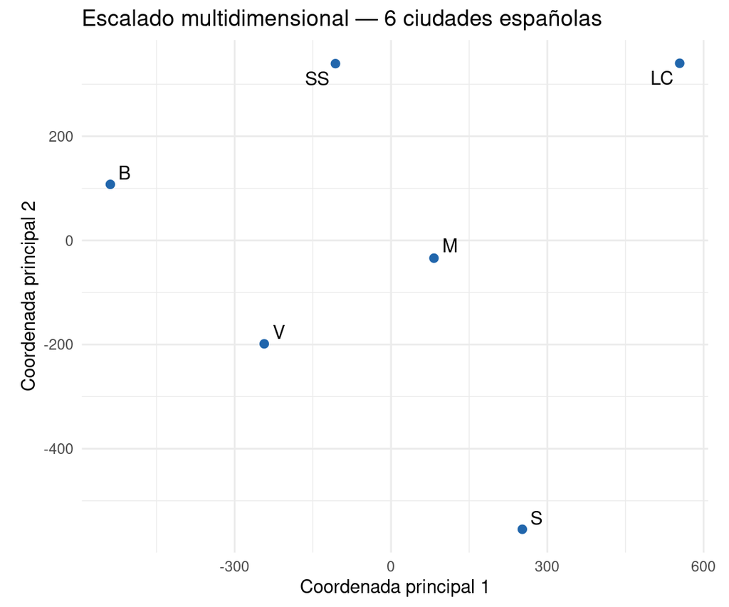

```r
mds_ciudades <- cmdscale(as.dist(ciudades), k = 2)
colnames(mds_ciudades) <- c("dim1", "dim2")

as_tibble(mds_ciudades, rownames = "ciudad") |>
  ggplot(aes(dim1, dim2, label = ciudad)) +
  geom_point(size = 2, colour = "#2166AC") +
  ggrepel::geom_text_repel() +
  coord_equal() +
  labs(title = "Escalado multidimensional — 6 ciudades españolas",
       x = "Coordenada principal 1", y = "Coordenada principal 2")
```

La disposición relativa de las ciudades reproduce razonablemente su geografía, aunque la solución queda determinada **salvo rotación, reflexión y traslación**: no hay nada en la matriz de distancias que le diga al algoritmo dónde está el norte. Por eso a veces hace falta invertir un eje a mano para que la orientación coincida con un mapa real.

Esto se aprecia mejor con un ejemplo más grande: `eurodist`, las distancias por carretera entre 21 ciudades europeas.

**Mostrar código**

```r
mds_eurodist <- cmdscale(eurodist, k = 2)

# Referencia para orientar los ejes: Estocolmo (norte) vs. Atenas (sur).
# Antes de invertir, Estocolmo tiene la segunda coordenada más negativa que
# Atenas, es decir que "sur" queda arriba: hay que invertir el eje 2 para
# que el norte quede hacia arriba, como en un mapa convencional.
orientacion_ns <- mds_eurodist["Stockholm", 2] < mds_eurodist["Athens", 2]
orientacion_ns
```

```
Stockholm
     TRUE
```

**Mostrar código**

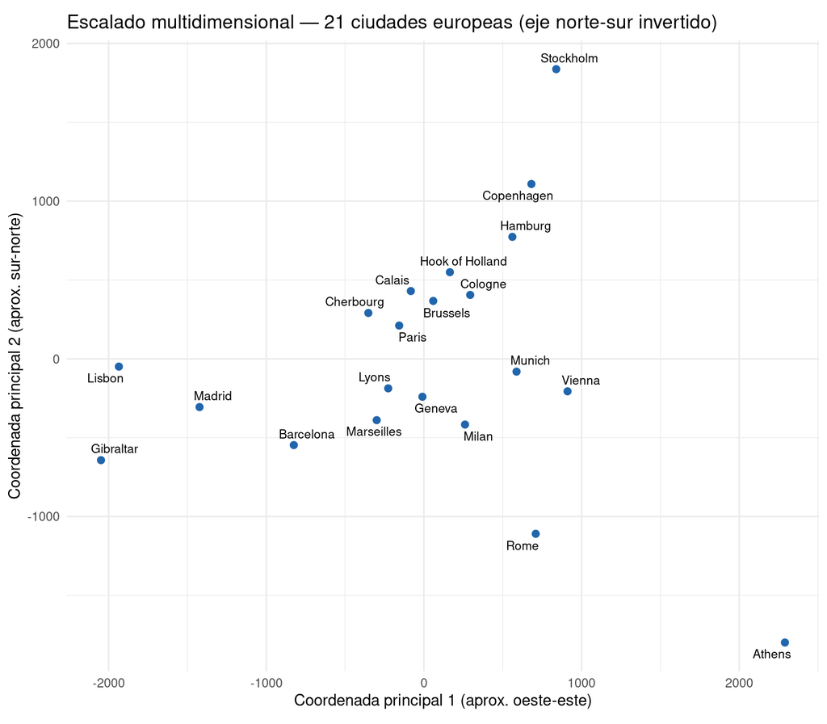

```r
mds_eurodist_orientado <- mds_eurodist
if (orientacion_ns) mds_eurodist_orientado[, 2] <- -mds_eurodist_orientado[, 2]
colnames(mds_eurodist_orientado) <- c("dim1", "dim2")

as_tibble(mds_eurodist_orientado, rownames = "ciudad") |>
  ggplot(aes(dim1, dim2, label = ciudad)) +
  geom_point(size = 2, colour = "#2166AC") +
  ggrepel::geom_text_repel(size = 3) +
  coord_equal() +
  labs(title = "Escalado multidimensional — 21 ciudades europeas (eje norte-sur invertido)",
       x = "Coordenada principal 1 (aprox. oeste-este)",
       y = "Coordenada principal 2 (aprox. sur-norte)")
```

Sin conocer ninguna coordenada geográfica, el mapa reconstruido ubica a Gibraltar y Lisboa al oeste, a Atenas al sureste y a Estocolmo al norte: la matriz de distancias por carretera contenía, de manera implícita, la disposición relativa de las ciudades.

## 3.2 Construcción de las coordenadas principales, paso a paso

Esta sección reproduce el cálculo que hace `cmdscale()` por dentro, sobre el ejemplo de las 6 ciudades españolas.

Partiendo de la matriz de distancias al cuadrado $\textbf{D}$, se construye la matriz de similitudes

$$\textbf{Q} = -\tfrac{1}{2}\,\textbf{P}\,\textbf{D}\,\textbf{P}, \qquad \textbf{P} = \textbf{I} - \tfrac{1}{n}\mathbf{1}\mathbf{1}'$$

**Mostrar código**

```r
D2 <- as.matrix(ciudades)^2
n_ciudades <- nrow(D2)

P <- diag(n_ciudades) - matrix(1 / n_ciudades, n_ciudades, n_ciudades)
Q <- -0.5 * P %*% D2 %*% P

round(Q, 1)
```

```
         [,1]      [,2]      [,3]      [,4]      [,5]      [,6]
[1,]  11759.4  -39079.2  -17954.4   38559.1  -31804.9   38519.9
[2,] -39079.2  303211.1  124211.4 -208389.6   73380.4 -253334.2
[3,] -17954.4  124211.4   75532.8   60951.3  -39894.2 -202846.9
[4,]  38559.1 -208389.6   60951.3  367858.8 -206103.7  -52875.9
[5,] -31804.9   73380.4  -39894.2 -206103.7  162774.8   41647.6
[6,]  38519.9 -253334.2 -202846.9  -52875.9   41647.6  428889.4
```

La misma matriz se obtiene elemento a elemento con el doble centrado

$$q_{ij} = -\tfrac{1}{2}\left(d_{ij}^2 - d_{i\cdot}^2 - d_{\cdot j}^2 + d_{\cdot\cdot}^2\right)$$

donde $d_{i\cdot}^2$ y $d_{\cdot j}^2$ son los promedios por fila y columna de $\textbf{D}^2$, y $d_{\cdot\cdot}^2$ el promedio general.

**Mostrar código**

```r
d2_fila <- rowMeans(D2)
d2_col  <- colMeans(D2)
d2_gral <- mean(D2)

Q_elemento <- outer(1:n_ciudades, 1:n_ciudades,
                     Vectorize(\(i, j) -0.5 * (D2[i, j] - d2_fila[i] - d2_col[j] + d2_gral)))
dimnames(Q_elemento) <- dimnames(Q)

stopifnot(isTRUE(all.equal(Q, Q_elemento)))

round(Q_elemento, 1)
```

```
         [,1]      [,2]      [,3]      [,4]      [,5]      [,6]
[1,]  11759.4  -39079.2  -17954.4   38559.1  -31804.9   38519.9
[2,] -39079.2  303211.1  124211.4 -208389.6   73380.4 -253334.2
[3,] -17954.4  124211.4   75532.8   60951.3  -39894.2 -202846.9
[4,]  38559.1 -208389.6   60951.3  367858.8 -206103.7  -52875.9
[5,] -31804.9   73380.4  -39894.2 -206103.7  162774.8   41647.6
[6,]  38519.9 -253334.2 -202846.9  -52875.9   41647.6  428889.4
```

Descomponiendo $\textbf{Q} = \textbf{V}\Lambda\textbf{V}'$, las coordenadas principales son $\textbf{Y} = \textbf{V}\Lambda^{1/2}$, tomando los $r$ primeros autovectores:

**Mostrar código**

```r
eQ <- eigen(Q)

Y_manual <- eQ$vectors[, 1:2] %*% diag(sqrt(eQ$values[1:2]))
dimnames(Y_manual) <- list(rownames(ciudades), c("Dim1", "Dim2"))

round(Y_manual, 1)
```

```
     Dim1   Dim2
M    82.4  -34.1
B  -538.6  107.7
V  -243.3 -198.6
S   252.0 -554.8
SS -106.6  339.5
LC  554.0  340.2
```

Y coincide con `cmdscale()`, salvo el signo de los ejes (una reflexión, que no cambia las distancias entre puntos):

**Mostrar código**

```r
stopifnot(isTRUE(all.equal(abs(as.numeric(Y_manual)),
                            abs(as.numeric(mds_ciudades)),
                            tolerance = 1e-6)))

round(abs(Y_manual), 1)
```

```
    Dim1  Dim2
M   82.4  34.1
B  538.6 107.7
V  243.3 198.6
S  252.0 554.8
SS 106.6 339.5
LC 554.0 340.2
```

**Mostrar código**

```r
round(abs(mds_ciudades), 1)
```

```
    dim1  dim2
M   82.4  34.1
B  538.6 107.7
V  243.3 198.6
S  252.0 554.8
SS 106.6 339.5
LC 554.0 340.2
```

Esto verifica que el cálculo manual reproduce `cmdscale()`, pero la equivalencia planteada en la introducción es otra: que el MDS clásico sobre distancias euclídeas **es** el ACP. `ciudades_espania` no sirve para comprobarlo, porque ya es una matriz de distancias, no de datos (no hay nada que estandarizar ni componentes que calcular sobre ella). Para eso hace falta una matriz de datos, y usamos `epf` (la que se retoma en la última parte de este práctico, para el análisis factorial): se estandariza, se calculan distancias euclídeas, y se compara el escalado multidimensional resultante contra las dos primeras componentes principales de los mismos datos estandarizados.

**Mostrar código**

```r
mds_epf <- cmdscale(dist(scale(epf)), k = 2)
pca_epf <- prcomp(scale(epf))

stopifnot(isTRUE(all.equal(abs(as.numeric(mds_epf)),
                            abs(as.numeric(pca_epf$x[, 1:2])),
                            tolerance = 1e-6)))

round(abs(mds_epf), 2)
```

```
      [,1] [,2]
 [1,] 1.38 0.90
 [2,] 0.14 0.13
 [3,] 1.29 0.76
 [4,] 1.69 0.13
 [5,] 0.47 0.54
 [6,] 4.69 0.16
 [7,] 0.12 0.69
 [8,] 0.14 0.39
 [9,] 1.36 0.98
[10,] 2.63 0.08
[11,] 0.59 0.00
[12,] 1.60 0.71
[13,] 2.40 1.24
[14,] 1.85 0.77
```

[output cut: 37 more lines]

**Mostrar código**

```r
round(abs(pca_epf$x[, 1:2]), 2)
```

```
       PC1  PC2
 [1,] 1.38 0.90
 [2,] 0.14 0.13
 [3,] 1.29 0.76
 [4,] 1.69 0.13
 [5,] 0.47 0.54
 [6,] 4.69 0.16
 [7,] 0.12 0.69
 [8,] 0.14 0.39
 [9,] 1.36 0.98
[10,] 2.63 0.08
[11,] 0.59 0.00
[12,] 1.60 0.71
[13,] 2.40 1.24
[14,] 1.85 0.77
```

[output cut: 37 more lines]

## 3.3 Compatibilidad con la métrica euclídea

El teorema detrás del método: $\textbf{D}$ es compatible con una métrica euclídea si la matriz $\textbf{Q}$ que se obtiene a partir de ella es semidefinida positiva, es decir, si todos sus autovalores son no negativos.

**Mostrar código**

```r
round(eQ$values, 1)
```

```
[1] 737916.9 591058.8  59468.7   1035.5      0.0 -39453.7
```

**Mostrar código**

```r
c(negativos = sum(eQ$values < -1e-6))
```

```
negativos
        1
```

`eurodist` tiene muchos más autovalores negativos que `ciudades_espania`:

**Mostrar código**

```r
eig_eurodist <- cmdscale(eurodist, k = 2, eig = TRUE)$eig

round(eig_eurodist, 0)
```

```
 [1] 19538377 11856555  1528844  1118742   789347   581655   262319   192598
 [9]   145085   107967    51395        0    -9496   -53058  -132217  -257336
[17]  -332672  -516252  -919149 -1006504 -2251844
```

**Mostrar código**

```r
c(negativos = sum(eig_eurodist < -1e-6))
```

```
negativos
        9
```

Por la restricción $\textbf{P}\mathbf{1} = 0$, la matriz $\textbf{Q}$ tiene rango máximo $n-1$: siempre aparece un autovalor exactamente cero (el asociado al vector $\mathbf{1}$), que no aporta ninguna dimensión.

`cmdscale(..., eig = TRUE)` devuelve además `$GOF`, la bondad de ajuste de la solución con $r$ dimensiones: qué proporción de la variabilidad se recupera con las dimensiones retenidas. Es un vector de dos medidas, que solo difieren en cómo tratan los autovalores negativos en el denominador: `GOF[1]` divide por la suma de los **valores absolutos** de todos los autovalores, y `GOF[2]` divide por la suma de los autovalores **positivos** únicamente. Ambas coinciden cuando no hay autovalores negativos, y se separan cuanto más se aparta la matriz de distancias de la métrica euclídea.

**Mostrar código**

```r
gof_ciudades  <- cmdscale(as.dist(ciudades), k = 2, eig = TRUE)$GOF
gof_eurodist  <- cmdscale(eurodist, k = 2, eig = TRUE)$GOF

tibble(medida = c("GOF[1] (denom. abs)", "GOF[2] (denom. positivos)"),
       ciudades = gof_ciudades, eurodist = gof_eurodist)
```

| medida | ciudades | eurodist |
| --- | --- | --- |
| GOF[1] (denom. abs) | 0.9300472 | 0.7537543 |
| GOF[2] (denom. positivos) | 0.9564555 | 0.8679134 |

En lo que sigue reportamos `GOF[2]`, la proporción de la variabilidad **recuperable** (la que queda después de descartar las dimensiones con autovalor negativo) que capturan las 2 dimensiones retenidas.

**Mostrar código**

```r
neg_ciudades <- sum(eQ$values < -1e-6)
neg_eurodist <- sum(eig_eurodist < -1e-6)

cat(glue::glue(
  "Ninguna de las dos matrices es exactamente compatible con una métrica euclídea, pero en distinta ",
  "medida: `ciudades_espania` tiene {neg_ciudades} autovalor negativo, contra {neg_eurodist} en `eurodist`. ",
  "Tiene sentido que eurodist se aparte más: son distancias por carretera entre ciudades de toda Europa, ",
  "separadas por mares y cordilleras que ninguna ruta cruza en línea recta, mientras que las seis ciudades ",
  "españolas están todas en la misma península. Aun con autovalores negativos, `cmdscale()` sigue dando ",
  "una solución útil: descarta esas dimensiones y se queda con las de mayor autovalor positivo. Ahí se ve ",
  "la diferencia entre los dos ejemplos: la bondad de ajuste con 2 dimensiones (GOF[2]) es del ",
  "{round(100 * gof_ciudades[2])}% para las ciudades españolas, contra un {round(100 * gof_eurodist[2])}% ",
  "más bajo para eurodist, coherente con que esta última matriz se aparta más de la geometría euclídea."
))
```

Ninguna de las dos matrices es exactamente compatible con una métrica euclídea, pero en distinta medida: `ciudades_espania` tiene 1 autovalor negativo, contra 9 en `eurodist`. Tiene sentido que eurodist se aparte más: son distancias por carretera entre ciudades de toda Europa, separadas por mares y cordilleras que ninguna ruta cruza en línea recta, mientras que las seis ciudades españolas están todas en la misma península. Aun con autovalores negativos, `cmdscale()` sigue dando una solución útil: descarta esas dimensiones y se queda con las de mayor autovalor positivo. Ahí se ve la diferencia entre los dos ejemplos: la bondad de ajuste con 2 dimensiones (GOF[2]) es del 96% para las ciudades españolas, contra un 87% más bajo para eurodist, coherente con que esta última matriz se aparta más de la geometría euclídea.

## 3.4 Escalado no métrico

Cuando lo único disponible son disimilitudes en escala **ordinal** (solo importa qué par es más o menos parecido, no la magnitud exacta), el MDS métrico ya no es apropiado. `productos.csv` trae disimilitudes entre 7 productos, en una escala subjetiva de 0 a 9:

**Mostrar código**

```r
productos
```

|  | A | B | C | D | E | F | G |
| --- | --- | --- | --- | --- | --- | --- | --- |
| A | 0 | 7 | 5 | 9 | 5 | 7 | 9 |
| B | 7 | 0 | 4 | 6 | 4 | 6 | 7 |
| C | 5 | 4 | 0 | 3 | 4 | 5 | 6 |
| D | 9 | 6 | 3 | 0 | 3 | 2 | 2 |
| E | 5 | 4 | 4 | 3 | 0 | 5 | 4 |
| F | 7 | 6 | 5 | 2 | 5 | 0 | 4 |
| G | 9 | 7 | 6 | 2 | 4 | 4 | 0 |

El escalado no métrico busca coordenadas cuyas distancias euclídeas $\hat{d}_{ij}$ se relacionen con las disimilitudes originales $s_{ij}$ mediante una función monótona **desconocida**: $s_{ij} = f(d_{ij})$. El criterio de ajuste habitual es el STRESS,

$$S^2 = \frac{\sum_{i<j}\left(s_{ij} - \hat{d}_{ij}\right)^2}{\sum_{i<j} s_{ij}^2}$$

**Mostrar código**

```r
d_productos <- as.dist(as.matrix(productos))
mds_no_metrico <- isoMDS(d_productos, k = 2, trace = FALSE)

mds_no_metrico$stress
```

```
[1] 7.08601
```

**Mostrar código**

```r
mds_no_metrico$points
```

```
        [,1]       [,2]
A  6.1365452  1.8289088
B  1.3142377 -4.5569073
C  2.3287162 -0.8903469
D -1.8105626  1.2392767
E -0.6958321 -2.1193530
F -1.8422913  4.2480542
G -5.4308132  0.2503675
```

**Mostrar código**

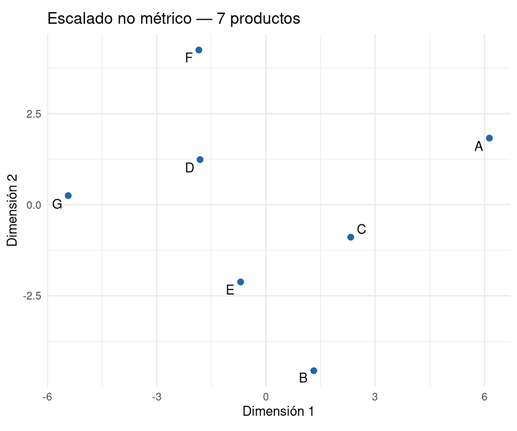

```r
mds_no_metrico_puntos <- mds_no_metrico$points
colnames(mds_no_metrico_puntos) <- c("dim1", "dim2")

as_tibble(mds_no_metrico_puntos, rownames = "producto") |>
  ggplot(aes(dim1, dim2, label = producto)) +
  geom_point(size = 2, colour = "#2166AC") +
  ggrepel::geom_text_repel() +
  coord_equal() +
  labs(title = "Escalado no métrico — 7 productos",
       x = "Dimensión 1", y = "Dimensión 2")
```

El diagrama de Shepard compara las disimilitudes originales contra las distancias ajustadas: si el ajuste fuera perfecto, los puntos seguirían una curva monótona creciente sin dispersión.

**Mostrar código**

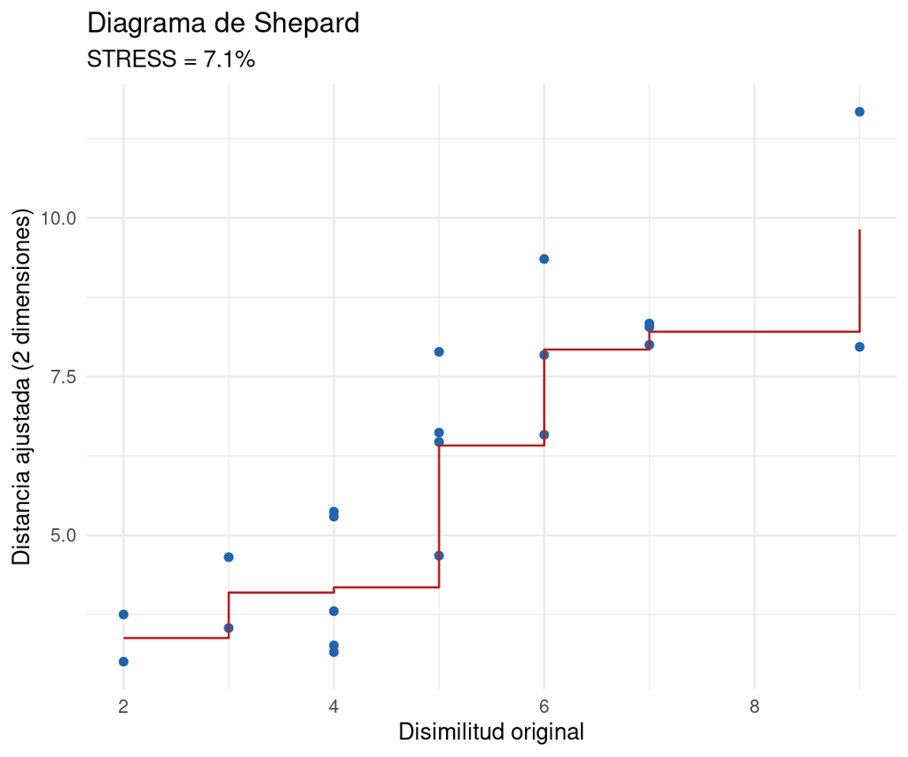

```r
d_ajustada <- dist(mds_no_metrico$points)

shepard <- tibble(disimilitud = as.numeric(d_productos),
                   distancia_ajustada = as.numeric(d_ajustada)) |>
  arrange(disimilitud)

ajuste_monotono <- isoreg(shepard$disimilitud, shepard$distancia_ajustada)

ggplot(shepard, aes(disimilitud, distancia_ajustada)) +
  geom_point(colour = "#2166AC") +
  geom_step(aes(y = ajuste_monotono$yf), colour = "firebrick") +
  labs(title = "Diagrama de Shepard", subtitle = paste0("STRESS = ", round(mds_no_metrico$stress, 1), "%"),
       x = "Disimilitud original", y = "Distancia ajustada (2 dimensiones)")
```

Con un STRESS de alrededor de 7, el ajuste es razonable: la relación entre disimilitudes y distancias es aproximadamente monótona, con algo de dispersión esperable dado que se trata de juicios subjetivos de disimilitud.

# 4 Análisis de correspondencias

## 4.1 Correspondencias simples, paso a paso

El análisis de correspondencias es el equivalente del ACP para **tablas de frecuencias**: en vez de partir de variables cuantitativas, parte de una tabla de contingencia entre dos variables categóricas y resume, en un espacio de pocas dimensiones, sus relaciones de asociación.

Trabajamos con la tabla cruzada entre `ESTCIV` y `NIVEL_ED` de `eph.csv`:

**Mostrar código**

```r
tabla_ca <- table(eph$ESTCIV, eph$NIVEL_ED)
tabla_ca
```

```
           primario secundario superior
  casado         55         44       39
  separado       11         16        9
  soltero         8          7       19
  unido          17          9        6
  viudo          35          3        4
```

Ya se ve una estructura clara: los viudos se concentran en nivel primario (35 de 42) y los solteros en nivel superior (19 de 34). El análisis debería recuperar esa asociación.

Partiendo de la matriz de frecuencias relativas $\textbf{F}$ y sus marginales $f_{i\cdot}$ (fila) y $f_{\cdot j}$ (columna):

**Mostrar código**

```r
n_ca <- sum(tabla_ca)
F_mat <- tabla_ca / n_ca

f_fila <- rowSums(F_mat)
f_col  <- colSums(F_mat)

round(F_mat, 3)
```

```
           primario secundario superior
  casado      0.195      0.156    0.138
  separado    0.039      0.057    0.032
  soltero     0.028      0.025    0.067
  unido       0.060      0.032    0.021
  viudo       0.124      0.011    0.014
```

Los **perfiles fila** son las frecuencias relativas de cada fila condicionadas a su propio total, $\textbf{R} = \textbf{D}_f^{-1}\textbf{F}$ con $\textbf{D}_f = \text{diag}(f_{i\cdot})$: describen la composición educativa dentro de cada estado civil.

**Mostrar código**

```r
Df_inv <- diag(1 / f_fila)
R_perfiles <- Df_inv %*% F_mat
dimnames(R_perfiles) <- dimnames(tabla_ca)

round(R_perfiles, 3)
```

```
           primario secundario superior
  casado      0.399      0.319    0.283
  separado    0.306      0.444    0.250
  soltero     0.235      0.206    0.559
  unido       0.531      0.281    0.188
  viudo       0.833      0.071    0.095
```

Los perfiles columna se construyen de forma análoga, $\textbf{C} = \textbf{D}_c^{-1}\textbf{F}'$.

Dos perfiles fila se comparan con la **distancia chi-cuadrado**, que pondera cada diferencia por la importancia de la columna correspondiente ($1/f_{\cdot j}$, más peso a las columnas con menor frecuencia):

$$d^2(i,i') = \sum_{j=1}^{c}\left(\frac{f_{ij}}{f_{i\cdot}} - \frac{f_{i'j}}{f_{i'\cdot}}\right)^2\frac{1}{f_{\cdot j}} = (\textbf{r}_i - \textbf{r}_{i'})'\textbf{D}_c^{-1}(\textbf{r}_i - \textbf{r}_{i'})$$

Esa distancia euclídea ponderada equivale a una distancia euclídea sin ponderar sobre los perfiles **transformados** $\textbf{Z}_F = \textbf{D}_f^{-1}\textbf{F}\textbf{D}_c^{-1/2}$ (y, análogamente, $\textbf{Z}_C = \textbf{D}_c^{-1}\textbf{F}'\textbf{D}_f^{-1/2}$ para columnas):

**Mostrar código**

```r
Dc_inv_medio <- diag(1 / sqrt(f_col))
Df_inv_medio <- diag(1 / sqrt(f_fila))

Zf <- Df_inv %*% F_mat %*% Dc_inv_medio
Zc <- diag(1 / f_col) %*% t(F_mat) %*% Df_inv_medio

round(Zf, 3)
```

```
      [,1]  [,2]  [,3]
[1,] 0.596 0.602 0.541
[2,] 0.457 0.840 0.478
[3,] 0.352 0.389 1.069
[4,] 0.795 0.531 0.359
[5,] 1.247 0.135 0.182
```

Las direcciones de proyección de máxima variabilidad se obtienen de la matriz $\textbf{Z} = \textbf{D}_f^{-1/2}\textbf{F}\textbf{D}_c^{-1/2}$, resolviendo $\textbf{Z}'\textbf{Z}\,\textbf{a} = \lambda\,\textbf{a}$. El mayor autovalor es siempre 1 (una solución trivial, asociada al vector de unos) y se descarta:

**Mostrar código**

```r
Z <- Df_inv_medio %*% F_mat %*% Dc_inv_medio

eZ <- eigen(t(Z) %*% Z)
round(eZ$values, 4)
```

```
[1] 1.0000 0.1317 0.0375
```

Con los autovectores $\textbf{A}$ (descartando el primero) se obtienen las coordenadas de las filas, $\textbf{C}_f = \textbf{D}_f^{-1}\textbf{F}\textbf{D}_c^{-1/2}\textbf{A}$:

**Mostrar código**

```r
A <- eZ$vectors[, 2:3]
lambda_ca <- eZ$values[2:3]

Cf_manual <- Df_inv %*% F_mat %*% Dc_inv_medio %*% A
dimnames(Cf_manual) <- list(rownames(tabla_ca), c("Dim1", "Dim2"))

round(Cf_manual, 3)
```

```
           Dim1   Dim2
casado   -0.091 -0.051
separado -0.249 -0.285
soltero  -0.486  0.427
unido     0.184 -0.094
viudo     0.766  0.138
```

Se verifica que coincide con `FactoMineR::CA()`, salvo el signo de cada eje (como en el MDS de la sección anterior, un autovector es solución tanto como su opuesto, así que la reflexión de un eje no es un error):

**Mostrar código**

```r
res_ca <- CA(tabla_ca, graph = FALSE)

stopifnot(isTRUE(all.equal(abs(as.numeric(Cf_manual)), abs(as.numeric(res_ca$row$coord)),
                            tolerance = 1e-6)))

round(res_ca$row$coord, 3)
```

```
          Dim 1  Dim 2
casado    0.091  0.051
separado  0.249  0.285
soltero   0.486 -0.427
unido    -0.184  0.094
viudo    -0.766 -0.138
```

Y, como contraste, con `ca::ca()`: sus valores singulares son la raíz cuadrada de los autovalores de $\textbf{Z}'\textbf{Z}$ (sin contar la solución trivial):

**Mostrar código**

```r
res_ca_pkg <- ca(tabla_ca)

stopifnot(isTRUE(all.equal(res_ca_pkg$sv, sqrt(lambda_ca), tolerance = 1e-6)))

c(valores_singulares_ca = res_ca_pkg$sv, raiz_autovalores_Z = sqrt(lambda_ca))
```

```
valores_singulares_ca1 valores_singulares_ca2    raiz_autovalores_Z1
             0.3628944              0.1935283              0.3628944
   raiz_autovalores_Z2
             0.1935283
```

## 4.2 Relación entre chi-cuadrado e inercia total

La **inercia total** del análisis, la suma de los autovalores no triviales de $\textbf{Z}'\textbf{Z}$, es el estadístico chi-cuadrado de independencia dividido por $n$.

$$\chi^2 = n \times IT \qquad\qquad IT = \frac{\chi^2}{n}$$

**Mostrar código**

```r
chi2 <- chisq.test(tabla_ca)$statistic
inercia_total <- sum(eZ$values[-1])

stopifnot(isTRUE(all.equal(as.numeric(chi2) / n_ca, inercia_total, tolerance = 1e-6)))

c(chi2 = as.numeric(chi2), inercia_total_x_n = inercia_total * n_ca)
```

```
             chi2 inercia_total_x_n
         47.69904          47.69904
```

Es una relación útil: la inercia total del análisis de correspondencias es, ni más ni menos, una medida de la fuerza de la asociación entre las dos variables categóricas, la misma que ya se conoce del test de independencia.

## 4.3 Interpretación y gráfico simétrico

`FactoMineR::CA()` calcula directamente coordenadas, contribuciones y calidad de representación ($\cos^2$) para filas y columnas:

**Mostrar código**

```r
res_ca$eig
```

```
      eigenvalue percentage of variance cumulative percentage of variance
dim 1  0.1316923               77.85741                          77.85741
dim 2  0.0374532               22.14259                         100.00000
```

**Mostrar código**

```r
res_ca$row$contrib
```

```
             Dim 1     Dim 2
casado    3.085690  3.382354
separado  5.987939 27.674800
soltero  21.655258 58.707619
unido     2.916872  2.701082
viudo    66.354241  7.534145
```

**Mostrar código**

```r
res_ca$row$cos2
```

```
             Dim 1      Dim 2
casado   0.7623451 0.23765495
separado 0.4320729 0.56792708
soltero  0.5646498 0.43535019
unido    0.7915404 0.20845958
viudo    0.9687182 0.03128176
```

**Mostrar código**

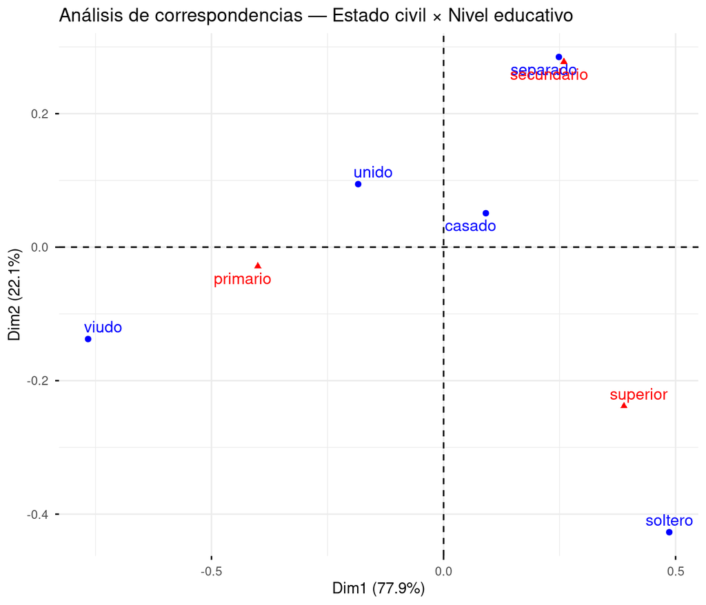

```r
fviz_ca_biplot(res_ca, repel = TRUE) +
  labs(title = "Análisis de correspondencias — Estado civil × Nivel educativo")
```

**AdvertenciaLectura del gráfico simétrico**

En el gráfico simétrico, filas y columnas se representan en un mismo plano, pero en dos nubes de puntos construidas con métricas distintas (una en el espacio de las columnas, la otra en el de las filas). Las distancias **dentro** de la nube de filas, o dentro de la nube de columnas, sí son interpretables como distancias chi-cuadrado entre perfiles. La distancia **entre** un punto fila y un punto columna, en cambio, no tiene una interpretación directa: solo puede leerse la dirección (un punto fila proyectado cerca de un punto columna sugiere asociación entre esas categorías), nunca la magnitud exacta de esa cercanía.

`soltero` y `superior` aparecen del mismo lado del gráfico, igual que `viudo` y `primario`, reflejando la asociación que ya se había visto en la tabla original.

**NotaOtro ejemplo: color de pelo y de ojos**

Un segundo ejemplo, más breve, con `HairEyeColor` (color de pelo y de ojos, sumando sobre la variable sexo):

**Mostrar código**

```r
tabla_haireye <- apply(HairEyeColor, c(1, 2), sum)
tabla_haireye
```

```
       Eye
Hair    Brown Blue Hazel Green
  Black    68   20    15     5
  Brown   119   84    54    29
  Red      26   17    14    14
  Blond     7   94    10    16
```

**Mostrar código**

```r
res_haireye <- CA(tabla_haireye, graph = FALSE)
res_haireye$eig
```

```
       eigenvalue percentage of variance cumulative percentage of variance
dim 1 0.208772652              89.372732                          89.37273
dim 2 0.022226615               9.514911                          98.88764
dim 3 0.002598439               1.112356                         100.00000
```

**Mostrar código**

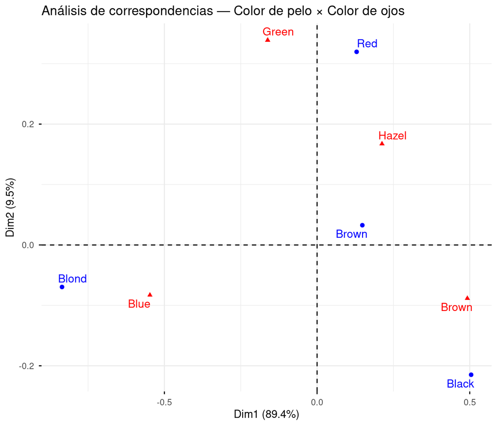

```r
fviz_ca_biplot(res_haireye, repel = TRUE) +
  labs(title = "Análisis de correspondencias — Color de pelo × Color de ojos")
```

La primera dimensión concentra la enorme mayoría de la inercia total, separando con claridad el extremo `Blond`/`Blue` del extremo `Black`/`Brown`: es la asociación esperable entre pelo y ojos claros, y entre pelo y ojos oscuros.

## 4.4 Correspondencias múltiples

Cuando hay más de dos variables categóricas, el análisis de correspondencias múltiples (ACM) trabaja sobre la **tabla disyuntiva completa**: una matriz $\textbf{Z}$ de $n$ filas (observaciones) y una columna por cada modalidad de cada variable, con 1 si la observación tiene esa modalidad y 0 si no.

**Mostrar código**

```r
Z_disyuntiva <- model.matrix(~ SEXO + ESTCIV + NIVEL_ED + ESTADO - 1, data = eph)

dim(Z_disyuntiva)
```

```
[1] 282  10
```

**Mostrar código**

```r
head(Z_disyuntiva)
```

```
  SEXOmujer SEXOvaron ESTCIVseparado ESTCIVsoltero ESTCIVunido ESTCIVviudo
1         0         1              0             0           0           0
2         0         1              0             0           0           0
3         0         1              0             1           0           0
4         0         1              0             0           0           0
5         0         1              0             0           0           0
6         0         1              0             0           0           1
  NIVEL_EDsecundario NIVEL_EDsuperior ESTADOinactivo ESTADOocupado
1                  1                0              0             1
2                  0                0              1             0
3                  0                1              0             1
4                  0                0              0             1
5                  1                0              1             0
6                  0                0              1             0
```

A partir de $\textbf{Z}$ se construye la **tabla de Burt** $\textbf{B} = \textbf{Z}'\textbf{Z}$: contiene, en cada bloque, la tabla de contingencia cruzada entre cada par de variables (y, en la diagonal, cada variable cruzada consigo misma). Es equivalente a la tabla disyuntiva para este análisis, y las dos producen los mismos factores.

**Mostrar código**

```r
burt <- t(Z_disyuntiva) %*% Z_disyuntiva

dim(burt)
```

```
[1] 10 10
```

**Mostrar código**

```r
burt[1:6, 1:6]
```

```
               SEXOmujer SEXOvaron ESTCIVseparado ESTCIVsoltero ESTCIVunido
SEXOmujer            100         0             24            25           9
SEXOvaron              0       182             12             9          23
ESTCIVseparado        24        12             36             0           0
ESTCIVsoltero         25         9              0            34           0
ESTCIVunido            9        23              0             0          32
ESTCIVviudo           33         9              0             0           0
               ESTCIVviudo
SEXOmujer               33
SEXOvaron                9
ESTCIVseparado           0
ESTCIVsoltero            0
ESTCIVunido              0
ESTCIVviudo             42
```

`FactoMineR::MCA()` no necesita que se construya la disyuntiva a mano: la genera internamente a partir del data frame de variables categóricas.

**Mostrar código**

```r
res_mca <- MCA(eph, graph = FALSE)

res_mca$eig[1:5, ]
```

```
      eigenvalue percentage of variance cumulative percentage of variance
dim 1  0.4832827              21.479230                          21.47923
dim 2  0.3601529              16.006797                          37.48603
dim 3  0.3166444              14.073085                          51.55911
dim 4  0.2802183              12.454147                          64.01326
dim 5  0.2077309               9.232484                          73.24574
```

**Mostrar código**

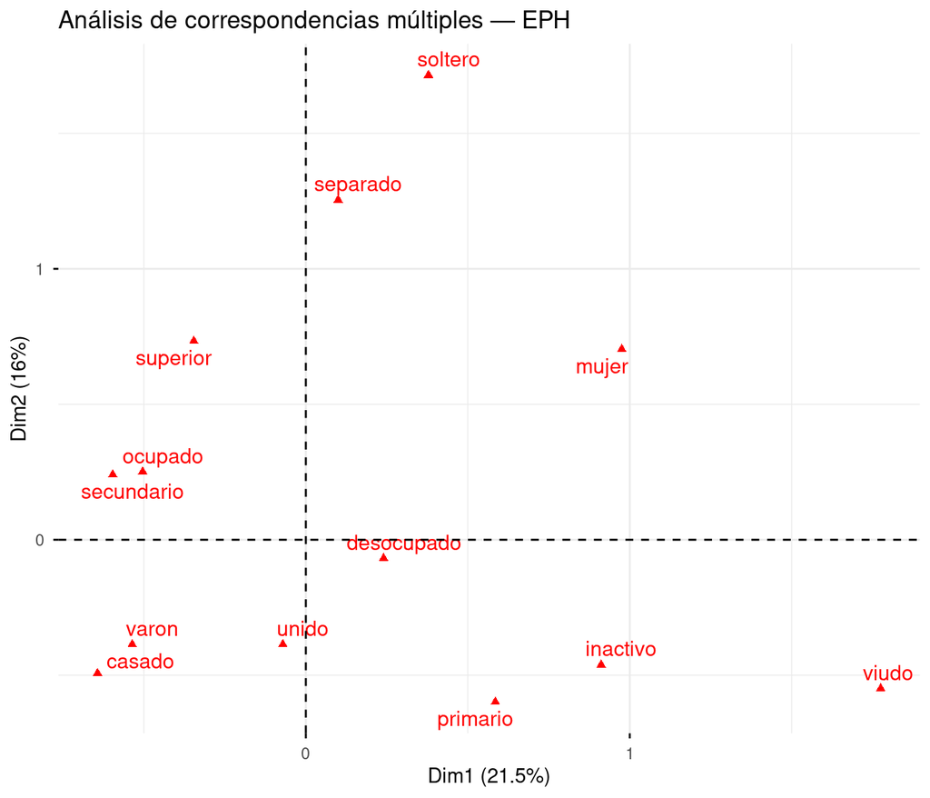

```r
fviz_mca_var(res_mca, repel = TRUE) +
  labs(title = "Análisis de correspondencias múltiples — EPH")
```

Lo que permite representar filas (individuos) y columnas (modalidades) sobre el mismo plano son las **fórmulas de transición** entre ambos espacios: cada nube de puntos puede reconstruirse a partir de la otra.

|  | Desde columnas | Desde filas |
| --- | --- | --- |
| Coordenadas de filas | $\textbf{C}_f = \dfrac{1}{\sqrt{\lambda}}\textbf{D}_f^{-1}\textbf{F}\,\textbf{C}_c$ |  |
| Coordenadas de columnas |  | $\textbf{C}_c = \dfrac{1}{\sqrt{\lambda}}\textbf{D}_c^{-1}\textbf{F}'\textbf{C}_f$ |

Se verifica sobre el ejemplo de correspondencias simples de la sección anterior: las coordenadas de fila deben poder reconstruirse a partir de las coordenadas de columna, escaladas por $1/\sqrt{\lambda}$.

**Mostrar código**

```r
Cc_ca <- res_ca$col$coord
Cf_desde_columnas <- sweep(Df_inv %*% F_mat %*% Cc_ca, 2, sqrt(lambda_ca), "/")

stopifnot(isTRUE(all.equal(as.matrix(Cf_desde_columnas), as.matrix(res_ca$row$coord),
                            check.attributes = FALSE, tolerance = 1e-6)))

round(Cf_desde_columnas, 3)
```

```
        Dim 1  Dim 2
  [1,]  0.091  0.051
  [2,]  0.249  0.285
  [3,]  0.486 -0.427
  [4,] -0.184  0.094
  [5,] -0.766 -0.138
```

# 5 Análisis Factorial Exploratorio

Trabajamos con `epf.csv`: el gasto de 51 provincias españolas en 9 grupos de rubros. A diferencia de los ejemplos anteriores, acá tiene sentido sustantivo pensar en patrones de consumo latentes (no observados directamente) que se manifiestan en los rubros de gasto observados.

**Mostrar código**

```r
epf
```

| alimentacion | vestido_calzado | vivienda | mobiliario | sanitarios | transporte | ensenanza_cultura | turismo_ocio | otros |
| --- | --- | --- | --- | --- | --- | --- | --- | --- |
| 618957 | 295452 | 522128 | 167067 | 58288 | 280035 | 129219 | 307967 | 107334 |
| 683940 | 203619 | 426690 | 124162 | 60657 | 285888 | 127792 | 313238 | 83523 |
| 590770 | 265604 | 487143 | 113386 | 37131 | 237320 | 116764 | 247536 | 79924 |
| 547353 | 238822 | 458338 | 119540 | 40340 | 236694 | 103901 | 272308 | 72813 |
| 649225 | 245722 | 570631 | 99250 | 61953 | 253286 | 123244 | 238880 | 83070 |
| 556210 | 183295 | 332662 | 86364 | 37160 | 136992 | 57607 | 189811 | 57311 |
| 617778 | 201348 | 508252 | 121010 | 63518 | 256973 | 128336 | 323632 | 93971 |
| 621570 | 208156 | 549399 | 137408 | 45101 | 298000 | 118269 | 308524 | 84514 |
| 577107 | 249310 | 412907 | 107976 | 39602 | 335334 | 90547 | 227266 | 92103 |
| 545238 | 199788 | 343919 | 122154 | 42281 | 224286 | 90291 | 237747 | 77938 |

[output cut: 41 more lines]

## 5.1 El modelo y en qué difiere del ACP

El modelo factorial expresa el vector de variables observadas como

$$\textbf{x} = \mu + \Lambda\textbf{f} + \textbf{u}, \qquad \textbf{f} \sim N_m(\textbf{0}, \textbf{I}), \quad \textbf{u} \sim N_p(\textbf{0}, \Psi)$$

con $\Lambda_{(p\times m)}$ las cargas factoriales, $\textbf{f}$ los $m$ factores comunes no observados y $\textbf{u}$ las perturbaciones específicas de cada variable, incorrelacionadas con los factores.

Esta es la diferencia central respecto del ACP, y conviene tenerla clara justo después de haber trabajado con componentes principales en la primera parte de la unidad: el ACP **transforma** los datos observados (las componentes se calculan de manera exacta, como combinación lineal de las variables), mientras que el análisis factorial **modela** los datos observados como generados por un número menor de factores latentes más un error específico por variable, con supuestos distribucionales que se pueden poner a prueba.

## 5.2 Estructura de la varianza

De $\textbf{x} = \mu + \Lambda\textbf{f} + \textbf{u}$ se sigue que la matriz de varianzas y covarianzas se descompone como

$$\textbf{V} = \Lambda\Lambda' + \Psi, \qquad \sigma_i^2 = \underbrace{\sum_{j=1}^{m}\lambda_{ij}^2}_{h_i^2 \text{ (comunalidad)}} + \underbrace{\psi_i^2}_{\text{específica}}$$

La comunalidad $h_i^2$ es la parte de la varianza de $x_i$ explicada por los factores comunes; la específica $\psi_i^2$, la que queda sin explicar. Ajustamos con 2 factores por máxima verosimilitud y comprobamos que ambas partes suman la varianza total (trabajando sobre la matriz de correlación, donde la varianza de cada variable vale 1):

**Mostrar código**

```r
fa_ml <- factanal(epf, factors = 2, scores = "regression")

comunalidad <- rowSums(fa_ml$loadings[, ]^2)
especifica  <- fa_ml$uniquenesses

tibble(variable = names(epf), comunalidad, especifica, suma = comunalidad + especifica)
```

| variable | comunalidad | especifica | suma |
| --- | --- | --- | --- |
| alimentacion | 0.3857681 | 0.61424061 | 1.0000087 |
| vestido_calzado | 0.4705415 | 0.52946162 | 1.0000031 |
| vivienda | 0.7313423 | 0.26865802 | 1.0000003 |
| mobiliario | 0.7179259 | 0.28207397 | 0.9999999 |
| sanitarios | 0.7014000 | 0.29860003 | 1.0000000 |
| transporte | 0.7823387 | 0.21766149 | 1.0000001 |
| ensenanza_cultura | 0.9741412 | 0.02585874 | 1.0000000 |
| turismo_ocio | 0.7612859 | 0.23871389 | 0.9999998 |
| otros | 0.6755520 | 0.32444763 | 0.9999996 |

**Mostrar código**

```r
# factanal() estima Lambda y Psi por optimización numérica (Newton-Raphson),
# no por una fórmula cerrada, así que la igualdad se cumple solo hasta la
# tolerancia de convergencia del algoritmo, no de forma exacta.
stopifnot(isTRUE(all.equal(as.numeric(comunalidad + especifica),
                            rep(1, ncol(epf)), tolerance = 1e-4)))

max(abs(comunalidad + especifica - 1))   # mayor desvío respecto de 1, dentro de la tolerancia numérica
```

```
[1] 8.671303e-06
```

## 5.3 Métodos de estimación

Hay tres formas usuales de estimar $\Lambda$ y $\Psi$: por componentes principales, por factor principal, y por máxima verosimilitud.

**Mostrar código**

```r
fa_cp <- principal(epf, nfactors = 2, rotate = "none")
fa_fp <- fa(epf, nfactors = 2, fm = "pa", rotate = "none")
# fa_ml ya se calculó arriba, con factanal()

tibble(
  variable          = names(epf),
  comunalidad_CP     = fa_cp$communality,
  comunalidad_FP     = fa_fp$communality,
  comunalidad_ML     = comunalidad
) |>
  mutate(across(where(is.numeric), ~round(.x, 3)))
```

| variable | comunalidad_CP | comunalidad_FP | comunalidad_ML |
| --- | --- | --- | --- |
| alimentacion | 0.705 | 0.431 | 0.386 |
| vestido_calzado | 0.729 | 0.571 | 0.471 |
| vivienda | 0.794 | 0.746 | 0.731 |
| mobiliario | 0.758 | 0.730 | 0.718 |
| sanitarios | 0.739 | 0.670 | 0.701 |
| transporte | 0.770 | 0.754 | 0.782 |
| ensenanza_cultura | 0.877 | 0.896 | 0.974 |
| turismo_ocio | 0.873 | 0.852 | 0.761 |
| otros | 0.619 | 0.574 | 0.676 |

Las tres soluciones son parecidas pero no idénticas: parten de criterios distintos (componentes principales maximiza varianza explicada sin modelo probabilístico de por medio; factor principal y máxima verosimilitud sí lo asumen, y se diferencian en cómo estiman iterativamente $\Psi$).

## 5.4 Número de factores

Además de los criterios ya vistos para ACP (sedimentación, porcentaje acumulado), la estimación por máxima verosimilitud permite un **contraste de hipótesis** formal sobre si $m$ factores alcanzan para explicar la estructura de covarianzas:

$$H_0: \textbf{V} = \Lambda\Lambda' + \Psi \qquad \text{vs.} \qquad H_1: \textbf{V} \neq \Lambda\Lambda' + \Psi$$

Es una diferencia importante respecto del ACP, donde la elección del número de componentes es puramente descriptiva: acá hay una prueba estadística de si el número de factores elegido es *suficiente*.

**Mostrar código**

```r
numero_factores <- tibble(
  m = 1:3,
  ajuste = map(m, \(m) factanal(epf, factors = m))
) |>
  mutate(
    chi2   = map_dbl(ajuste, \(a) a$STATISTIC),
    gl     = map_dbl(ajuste, \(a) a$dof),
    p_valor = map_dbl(ajuste, \(a) a$PVAL)
  ) |>
  select(-ajuste)

numero_factores
```

| m | chi2 | gl | p_valor |
| --- | --- | --- | --- |
| 1 | 38.288024 | 27 | 0.07342176 |
| 2 | 18.143752 | 19 | 0.51285585 |
| 3 | 7.270787 | 12 | 0.83921227 |

Con 1 factor el ajuste es apenas aceptable ($p \approx 0.07$, cerca del umbral habitual de 0.05); con 2 factores el test no rechaza $H_0$ con holgura ($p \approx 0.51$). Trabajamos con **2 factores** en lo que sigue: es el número más chico que da un ajuste claramente aceptable, y todavía deja una estructura interpretable.

## 5.5 Rotación

La matriz de cargas no está identificada de forma única: cualquier rotación ortogonal de $\Lambda$ reproduce la misma matriz de varianzas y covarianzas. Se aprovecha esa libertad para buscar una solución más fácil de interpretar, sin cambiar el ajuste del modelo.

- **Varimax**: maximiza la varianza de las cargas al cuadrado dentro de cada factor (opera sobre columnas de $\Lambda$); busca que cada factor tenga pocas variables con carga alta.
- **Quartimax**: maximiza la dispersión de las cargas dentro de cada variable, entre factores (opera sobre filas); busca que cada variable cargue fuerte en pocos factores.

**Mostrar código**

```r
fa_varimax   <- factanal(epf, factors = 2, rotation = "varimax")
fa_quartimax <- factanal(epf, factors = 2, rotation = "quartimax")

round(cbind(sin_rotar = fa_ml$loadings[, 1],
            varimax   = fa_varimax$loadings[, 1],
            quartimax = fa_quartimax$loadings[, 1]), 3)
```

```
                  sin_rotar varimax quartimax
alimentacion          0.460   0.460     0.620
vestido_calzado       0.357   0.357     0.643
vivienda              0.738   0.738     0.847
mobiliario            0.575   0.575     0.837
sanitarios            0.687   0.687     0.836
transporte            0.525   0.525     0.853
ensenanza_cultura     0.914   0.914     0.948
turismo_ocio          0.738   0.738     0.868
otros                 0.304   0.304     0.712
```

Con la solución varimax completa (las dos cargas de cada rubro) se puede intentar una lectura sustantiva:

**Mostrar código**

```r
round(fa_varimax$loadings[, 1:2], 3)
```

```
                  Factor1 Factor2
alimentacion        0.460   0.417
vestido_calzado     0.357   0.586
vivienda            0.738   0.432
mobiliario          0.575   0.622
sanitarios          0.687   0.479
transporte          0.525   0.712
ensenanza_cultura   0.914   0.373
turismo_ocio        0.738   0.466
otros               0.304   0.764
```

Las dos cargas son positivas en casi todos los rubros (esperable en datos de gasto, donde todas las categorías tienden a subir juntas con el nivel de gasto total de la provincia), pero hay una diferencia relativa: el Factor 1 pesa comparativamente más en `ensenanza_cultura`, `vivienda` y `turismo_ocio`, mientras que el Factor 2 pesa comparativamente más en `otros`, `transporte` y `vestido_calzado`.

Las cargas cambian con la rotación, pero las comunalidades (y por lo tanto el ajuste del modelo) no:

**Mostrar código**

```r
com_varimax   <- rowSums(fa_varimax$loadings[, ]^2)
com_quartimax <- rowSums(fa_quartimax$loadings[, ]^2)

stopifnot(
  isTRUE(all.equal(comunalidad, com_varimax, tolerance = 1e-6)),
  isTRUE(all.equal(comunalidad, com_quartimax, tolerance = 1e-6))
)

tibble(variable = names(epf), sin_rotar = comunalidad, varimax = com_varimax, quartimax = com_quartimax)
```

| variable | sin_rotar | varimax | quartimax |
| --- | --- | --- | --- |
| alimentacion | 0.3857681 | 0.3857681 | 0.3857681 |
| vestido_calzado | 0.4705415 | 0.4705415 | 0.4705415 |
| vivienda | 0.7313423 | 0.7313423 | 0.7313423 |
| mobiliario | 0.7179259 | 0.7179259 | 0.7179259 |
| sanitarios | 0.7014000 | 0.7014000 | 0.7014000 |
| transporte | 0.7823387 | 0.7823387 | 0.7823387 |
| ensenanza_cultura | 0.9741412 | 0.9741412 | 0.9741412 |
| turismo_ocio | 0.7612859 | 0.7612859 | 0.7612859 |
| otros | 0.6755520 | 0.6755520 | 0.6755520 |

La rotación solo cambia la interpretación (qué variables se asocian con cada factor), no la calidad del ajuste.

## 5.6 Puntuaciones factoriales

Una vez estimado el modelo, interesa saber qué valor toma cada factor en cada observación (cada provincia). Hay dos enfoques, según si los factores se tratan como parámetros o como variables aleatorias:

- **Bartlett**: trata $\textbf{f}_i$ como un parámetro a estimar por mínimos cuadrados generalizados, $\hat{\textbf{f}}_i = (\hat\Lambda'\hat\Psi^{-1}\hat\Lambda)^{-1}\hat\Lambda'\hat\Psi^{-1}\textbf{x}_i$.
- **Regresión (Thomson)**: trata $\textbf{f}_i$ como una variable aleatoria y predice con la esperanza condicional, $\hat{\textbf{f}}_i = E(\textbf{f}_i \mid \textbf{x}_i)$.

**Mostrar código**

```r
fa_bartlett <- factanal(epf, factors = 2, scores = "Bartlett")

puntuaciones <- tibble(
  provincia       = seq_len(nrow(epf)),
  bartlett_f1     = fa_bartlett$scores[, 1],
  regresion_f1    = fa_ml$scores[, 1]
)

puntuaciones
```

| provincia | bartlett_f1 | regresion_f1 |
| --- | --- | --- |
| 1 | -0.29190150 | -0.154530380 |
| 2 | 0.32207175 | 0.234633820 |
| 3 | 0.12375945 | 0.002789249 |
| 4 | -0.19597272 | -0.280322148 |
| 5 | 0.35821983 | 0.224221208 |
| 6 | -0.98371785 | -1.131031675 |
| 7 | 0.42582225 | 0.316468987 |
| 8 | -0.08919808 | -0.089424010 |
| 9 | -1.34990216 | -1.148087671 |
| 10 | -0.64391772 | -0.685281376 |

[output cut: 41 more lines]

**Mostrar código**

```r
cor(puntuaciones$bartlett_f1, puntuaciones$regresion_f1)
```

```
[1] 0.9911752
```

**Mostrar código**

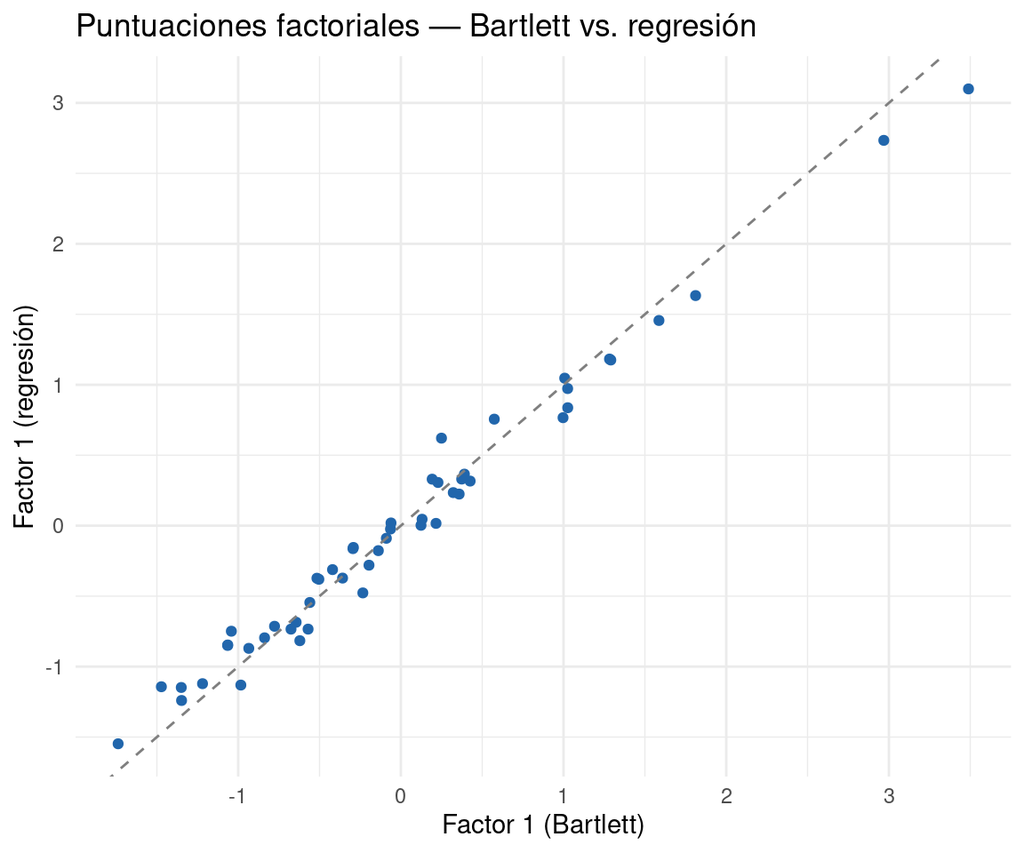

```r
ggplot(puntuaciones, aes(bartlett_f1, regresion_f1)) +
  geom_point(colour = "#2166AC") +
  geom_abline(linetype = "dashed", colour = "grey50") +
  labs(title = "Puntuaciones factoriales — Bartlett vs. regresión",
       x = "Factor 1 (Bartlett)", y = "Factor 1 (regresión)")
```

Las dos puntuaciones están muy correlacionadas pero no son idénticas: son dos estimadores distintos del mismo factor no observado, y difieren porque parten de supuestos distintos sobre qué es $\textbf{f}_i$ (un parámetro fijo o una variable aleatoria).

# 6 Referencias

- Peña, D. (2002). *Análisis de Datos Multivariantes*. McGraw-Hill.
- Härdle, W. y Simar, L. (2015). *Applied Multivariate Statistical Analysis* (4ta ed.). Springer.
- Johnson, R. A. y Wichern, D. W. (2007). *Applied Multivariate Statistical Analysis* (6ta ed.). Pearson.
- Greenacre, M. (2017). *Correspondence Analysis in Practice* (3ra ed.). CRC Press.
- Bartlett, M. S. (1954). A note on the multiplying factors for various $\chi^2$ approximations. *Journal of the Royal Statistical Society, Series B*, 16(2), 296–298.